# Лабораторная работа №2

Операционные системы

Кузьмин Егор Витальевич, НКАбд-03-23

Российский университет дружбы народов, Москва, Россия

27 февраля 2024

## Цель работы

Целью данной лабораторной работы является изучение идеологии и получение практических навыков в применении средств контроля версий и работе с git.

## Задание

0. Базовое ознакомление с git
1. Создать базовую конфигурацию для работы с git
2. Создать ключ SSH
3. Создать ключ GPG
4. Настроить подписи Git
5. Заргеистрироваться на GitHub
6. Создать локальный каталог для выполнения заданий по предмету.

## Выполнение лабораторной работы. Установка ПО.

Устанавливаю необходимое программное обеспечение git и gh (рис. 1).

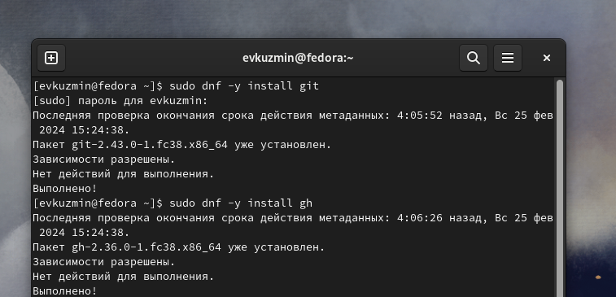

Установка git и gh

## Выполнение лабораторной работы. Базовая настройка git

Настраивание конфига git (рис. 2).

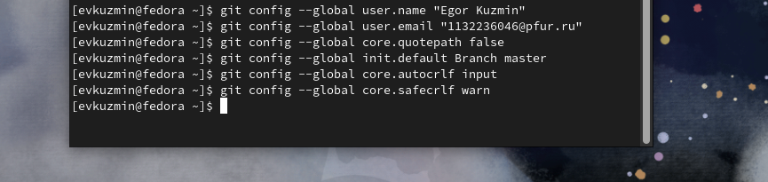

Найстройка конфига git

## Выполнение лабораторной работы. Создание ключа SSH

Создаю ключ ssh размером 4096 бит по алгоритму rsa (рис. 3).

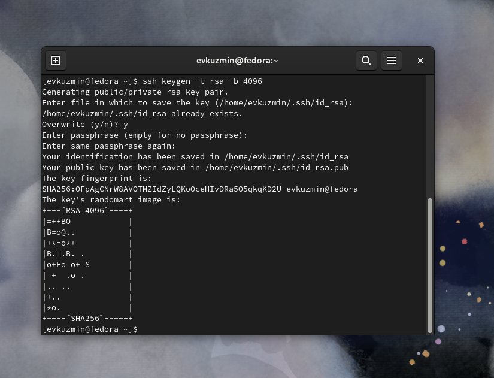

Генерация ssh ключа по алгоритму rsa

## Выполнение лабораторной работы. Создание ключа SSH

Создаю ключ ssh по алгоритму ed25519 (рис. 4).

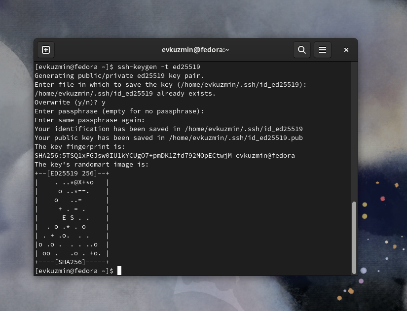

Генерация ssh ключа по алгоритму ed25519

## Выполнение лабораторной работы. Создание ключа GPG

Генерирую ключ GPG, затем выбираю тип ключа RSA, задаю максиммальную длину ключа: 4096, выбираю неограниченный срок действия ключа. Завершаем настройку (рис. 5).

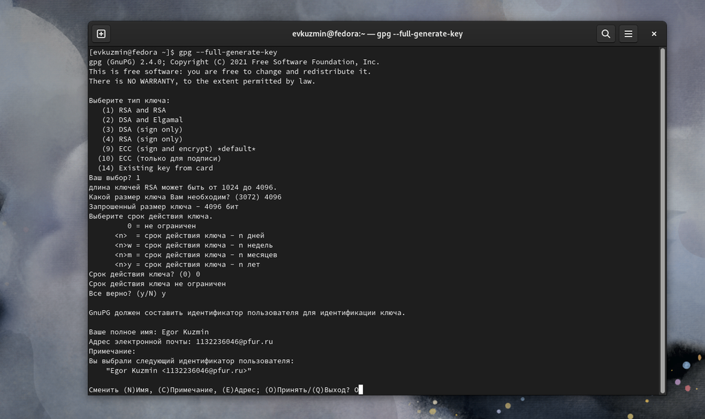

Генерация ключа

## Выполнение лабораторной работы. Регистрация на Github

У меня уже был создан аккаунт на Github, соответственно просто вхожу в свой аккаунт.

## Выполнение лабораторной работы. Добавление ключа GPG в Github

- Вывожу список созданных ключей в терминал
- Ищу в результате запроса отпечаток ключа
- Копирую его в буфер обмена
- Ввожу в терминале команду, с помощью которой копирую сам ключ GPG в буфер обмена (рис. 6).

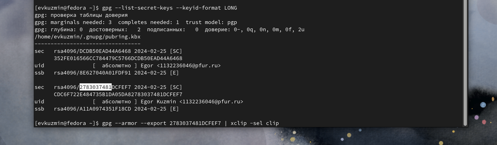

Вывод списка ключей

## Выполнение лабораторной работы. Добавление ключа GPG в Github

Мы видим добавленный ключ GPG на GitHub (рис. 7}.

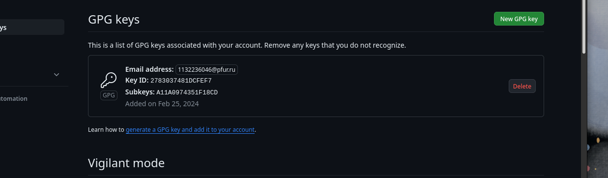

Добавленный ключ GPG

## Выполнение лабораторной работы. Настроить подписи Git

Настраиваю автоматические подписи коммитов git (рис. 8).

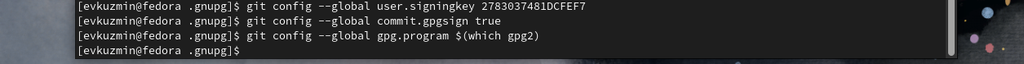

Настройка подписей Git

## Выполнение лабораторной работы. Настройка gh

- Начинаю авторизацию в gh
- Отвечаю на вопросы
- В конце выбираю авторизоваться через браузер (рис. 9).

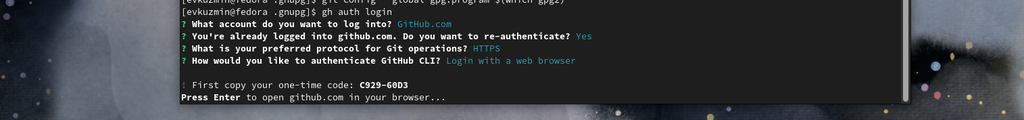

Авторизация в gh

## Выполнение лабораторной работы. Настройка gh

Завершаю авторизацию на сайте (рис. 10).

[figure not shown]

Завершение авторизации через браузер

## Выполнение лабораторной работы. Создание репозитория курса на основе шаблона

- Создаю директорию с помощью утилиты mkdir
- Перехожу в созданную директорию
- Создаю репозиторий
- После этого клонирую репозиторий к себе в директорию (рис. 11).

[figure not shown]

Создание репозитория

## Выполнение лабораторной работы. Создание репозитория курса на основе шаблона

- Перехожу в каталог курса
- Проверяю содержание каталога
- Удаляю лишние файлы
- Создаю необходимые каталоги, используя makefile
- Сохраняю добавленные изменения
- Комментирую их с помощью git commit (рис. 12).

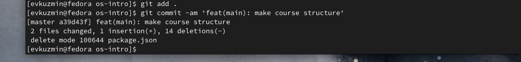

Работа директориями

## Выполнение лабораторной работы. Создание репозитория курса на основе шаблона

Отправляю файлы на сервер с помощью git push (рис. 013).

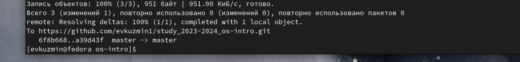

Отправка файлов на сервер

## Выводы

При выполнении данной лабораторной работы я приобрел практические навыки по применению средств контроля версий и работе с git.

## Список литературы

[Архитектура компьютеров и ОС/Электронный ресурс](https://esystem.rudn.ru/mod/page/view.php?id=1098790)